# Convolutional Neural Networks Assignment-Fashion MNIST Dataset

```python
import numpy as np
np.random.seed(23)
```

```python
import keras
from keras.datasets import fashion_mnist
from keras.models import Sequential
from keras.layers import Dense
from keras.optimizers import SGD
import matplotlib.pyplot as plt
from keras import layers
```

```python
!pip freeze | grep tensorflow
```

```
tensorflow==2.17.1
tensorflow-datasets==4.9.7
tensorflow-hub==0.16.1
tensorflow-io-gcs-filesystem==0.37.1
tensorflow-metadata==1.13.1
tensorflow-probability==0.24.0
```

### Load Dataset- FASHION MNIST

The Fashion MNIST dataset is a collection of grayscale images of clothing and accessories. It's intended to be a drop-in replacement for the classic MNIST dataset, which contains handwritten digits. Here are some key characteristics:

1. Images: 70,000 grayscale images in total. The dataset is divided into a training set of 60,000 images and a test set of 10,000 images. Each image is 28x28 pixels.
2. Categories: 10 different categories of clothing and accessories, such as t-shirts, trousers, pullovers, dresses, coats, sandals, shirts, sneakers, bags, and ankle boots.
3. Loading and Preparing Data: Use FASHION MNIST dataset's load_data method to import training and validation sets.

Training data (x_train) are input pixels; y_train are corresponding labels. Validation data is used to assess model performance on unseen data.

```python
(X_train, y_train), (X_test, y_test) = fashion_mnist.load_data()
```

```
Downloading data from https://storage.googleapis.com/tensorflow/tf-keras-datasets/train-labels-idx1-ubyte.gz
29515/29515 ━━━━━━━━━━━━━━━━━━━━ 0s 0us/step
Downloading data from https://storage.googleapis.com/tensorflow/tf-keras-datasets/train-images-idx3-ubyte.gz
26421880/26421880 ━━━━━━━━━━━━━━━━━━━━ 0s 0us/step
Downloading data from https://storage.googleapis.com/tensorflow/tf-keras-datasets/t10k-labels-idx1-ubyte.gz
5148/5148 ━━━━━━━━━━━━━━━━━━━━ 0s 1us/step
Downloading data from https://storage.googleapis.com/tensorflow/tf-keras-datasets/t10k-images-idx3-ubyte.gz
4422102/4422102 ━━━━━━━━━━━━━━━━━━━━ 0s 0us/step
```

```python
X_train.shape
```

```
(60000, 28, 28)
```

```python
y_train.shape
```

```
(60000,)
```

```python
X_test.shape
```

```
(10000, 28, 28)
```

```python
y_test.shape
```

```
(10000,)
```

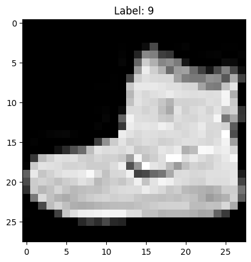

```python
image_index = 0  # You can change this to any number between 0 and 59999
selected_image = X_train[image_index]
plt.imshow(selected_image, cmap='gray')
plt.title(f'Label: {y_train[image_index]}')
plt.show()
```

[figure not shown]

```python
plt.figure(figsize=(5,5))
for k in range(16):
    plt.subplot(4, 4, k+1)
    plt.imshow(X_train[k], cmap='Greys')
    plt.axis('off')
plt.tight_layout()
plt.show()
```

```python
y_train[0:99]
```

```
array([9, 0, 0, 3, 0, 2, 7, 2, 5, 5, 0, 9, 5, 5, 7, 9, 1, 0, 6, 4, 3, 1,
       4, 8, 4, 3, 0, 2, 4, 4, 5, 3, 6, 6, 0, 8, 5, 2, 1, 6, 6, 7, 9, 5,
       9, 2, 7, 3, 0, 3, 3, 3, 7, 2, 2, 6, 6, 8, 3, 3, 5, 0, 5, 5, 0, 2,
       0, 0, 4, 1, 3, 1, 6, 3, 1, 4, 4, 6, 1, 9, 1, 3, 5, 7, 9, 7, 1, 7,
       9, 9, 9, 3, 2, 9, 3, 6, 4, 1, 1], dtype=uint8)
```

```python
y_test[0]
```

```
9
```

### **Preprocess data**

**Preprocessing the Data for CNN**:

Convert the pixel values to 32-bit floats. Normalize pixel values within the range [0, 1] by dividing by 255. By normalizing our pixel values to within the range [0, 1], the darkest pixels will approach a value of 1, while the white pixels will be represented by 0s.

**Normalization:** The pixel values in the images are originally integers ranging from 0 to 255. These values are divided by 255 to normalize them to the range [0, 1]. Normalization is a common preprocessing step in deep learning as it helps to stabilize and speed up training by keeping input values small. When converting the pixel values of the FASHION MNIST dataset to be between 0 and 1, these values need to be stored as floating-point numbers (not integers) because the normalized values are decimals. Using float32 allows for proper handling of these normalized values.

**Precision and Efficiency Trade-off:** Neural networks typically work well with 32-bit floating point numbers (float32), as they provide sufficient precision for the vast majority of machine learning tasks, including deep learning, while being computationally efficient. Using a higher precision (like float64) would increase memory usage and computation time without significantly improving the performance for most tasks.

**Consistent Input Scale**: It ensures that the input features (in this case, pixel values) are on a consistent scale, which helps the learning algorithm perform better and converge faster during training.

**Input Image Shape**: It ensures that images have the right shape, in this case, (28,28,1) where the 1 represents that those are grayscale images with 1 color channel

```python
# Scale images to the [0, 1] range
X_train = X_train.astype("float32") / 255
X_test = X_test.astype("float32") / 255
# Make sure images have shape (28, 28, 1)
X_train = np.expand_dims(X_train, -1)
X_test = np.expand_dims(X_test, -1)

print(X_train.shape[0], 'train samples')
print(X_test.shape[0], 'test samples')
```

```
60000 train samples
10000 test samples
```

**Preprocess the labels for the images:**

Since there are ten classes of clothing and accessories, each represented by a digit ranging from 0 through 9, they need to be represented in a format suitable for classification. The integer labels are transformed into a one-hot encoded format using Keras's categorical utility. One-hot encoding converts an integer label into a 10-element array where all elements are 0 except for the index corresponding to the label, which is set to 1. For example, the shoe, which correpsonds to label '9' will be represented as an array where the 9th index is 1, and all other indices are 0. This representation is optimal for classification tasks, as it allows the neural network to output a distinct probability for each class. When the network is given an image of a shoe, the ideal outcome is for it to assign a 100% probability to the '9' class and '0' to all other classes. This desired outcome is what we train the model to achieve through the learning process.

```python
n_classes = 10
y_train = keras.utils.to_categorical(y_train, n_classes)
y_test = keras.utils.to_categorical(y_test, n_classes)
```

```python
y_test[0]
```

```
array([0., 0., 0., 0., 0., 0., 0., 0., 0., 1.])
```

We already know that X_test[0] is a shoe, and X_train[0] also happened to be a shoe, so we found out that the label digit associated with the shoe is 9. Therefore, seeing that y_test[0] is a binary matrix of zeroes expect for the last index, we can be confident that the one-hot encoding works properly for our code.

## CNN Model Design and Experimentation

### Initial Model using Relu activation for CNN

1. Input Layer:

This layer receives the raw image data. In my code, keras.Input(shape=input_shape) defines the input layer, expecting images of size 28x28 pixels with 1 channel (grayscale). 2. Convolutional Layers: These layers are the core of a CNN. They apply filters (kernels) to the input image to extract features. layers.Conv2D(32, kernel_size=(3, 3), activation="relu") defines the first convolutional layer in my model. It uses 32 filters, each with a size of 3x3 pixels. The activation function is ReLU. layers.Conv2D(64, kernel_size=(3, 3), activation="relu") defines a second convolutional layer, similar to the first but with 64 filters. The filters learn to detect patterns in the image, such as edges, corners, or textures. 3. Max Pooling Layers: These layers reduce the spatial dimensions of the feature maps outputted by the convolutional layers. layers.MaxPooling2D(pool_size=(2, 2)) defines a max pooling layer with a pool size of 2x2. Max pooling selects the maximum value within each pool, downsampling the feature maps while retaining important information. This process makes the model more robust to small variations in the input. 4. Flatten Layer: This layer converts the multi-dimensional feature maps into a single, long vector. layers.Flatten() performs this operation in my code. This is necessary to connect the convolutional layers to the fully connected layers that follow. 5. Dropout Layer: This layer randomly sets a fraction of input units to 0 during training, which helps prevent overfitting. layers.Dropout(0.5) applies dropout with a rate of 0.5, meaning 50% of the units will be dropped during each training iteration. 6. Dense (Fully Connected) Layer: This layer performs classification based on the extracted features. layers.Dense(num_classes, activation="softmax") defines a dense layer with num_classes (10 in your case) output units and a softmax activation function. The softmax activation produces a probability distribution over the different classes, indicating the model's prediction for the input image. 7. Output Layer: This layer presents the final output of the model, typically a prediction or classification. In this model, the dense layer with softmax activation acts as the output layer. It provides the probabilities for each of the 10 clothing categories.

```python
# Model / data parameters
num_classes = 10
input_shape = (28, 28, 1)

model = keras.Sequential(
    [
        keras.Input(shape=input_shape),
        layers.Conv2D(32, kernel_size=(3, 3), activation="relu"),
        layers.MaxPooling2D(pool_size=(2, 2)),
        layers.Conv2D(64, kernel_size=(3, 3), activation="relu"),
        layers.MaxPooling2D(pool_size=(2, 2)),
        layers.Flatten(),
        layers.Dropout(0.5),
        layers.Dense(num_classes, activation="softmax"),
    ]
)
model.summary()
```

```
Model: "sequential"
```

```
┏━━━━━━━━━━━━━━━━━━━━━━━━━━━━━━━━━━━━━━┳━━━━━━━━━━━━━━━━━━━━━━━━━━━━━┳━━━━━━━━━━━━━━━━━┓
┃ Layer (type)                         ┃ Output Shape                ┃         Param # ┃
┡━━━━━━━━━━━━━━━━━━━━━━━━━━━━━━━━━━━━━━╇━━━━━━━━━━━━━━━━━━━━━━━━━━━━━╇━━━━━━━━━━━━━━━━━┩
│ conv2d (Conv2D)                      │ (None, 26, 26, 32)          │             320 │
├──────────────────────────────────────┼─────────────────────────────┼─────────────────┤
│ max_pooling2d (MaxPooling2D)         │ (None, 13, 13, 32)          │               0 │
├──────────────────────────────────────┼─────────────────────────────┼─────────────────┤
│ conv2d_1 (Conv2D)                    │ (None, 11, 11, 64)          │          18,496 │
├──────────────────────────────────────┼─────────────────────────────┼─────────────────┤
│ max_pooling2d_1 (MaxPooling2D)       │ (None, 5, 5, 64)            │               0 │
├──────────────────────────────────────┼─────────────────────────────┼─────────────────┤
│ flatten (Flatten)                    │ (None, 1600)                │               0 │
├──────────────────────────────────────┼─────────────────────────────┼─────────────────┤
│ dropout (Dropout)                    │ (None, 1600)                │               0 │
├──────────────────────────────────────┼─────────────────────────────┼─────────────────┤
│ dense (Dense)                        │ (None, 10)                  │          16,010 │
└──────────────────────────────────────┴─────────────────────────────┴─────────────────┘
```

```
 Total params: 34,826 (136.04 KB)
```

```
 Trainable params: 34,826 (136.04 KB)
```

```
 Non-trainable params: 0 (0.00 B)
```

#### Model Parameter Summary

1. The first convolutional layer has 32 filters with a size of 3x3 and 1 input channel and 1 bias term: (3x3x1+1)x32 = 320 parameters.
2. The second layer follows the same logic so the number of parameters generated is (3x3x32+1)x64=18,496 since the input channels are the 32 channelts that come out of the first layer.
3. The dense layer is applied on the flattened network (5x5x64)=1600. Each neuron out of the 10 in output layer has a bias so the number of parameters is (1600+1)*10=16,010.
4. Max pooling, flatten, and dropout layers do not have any trainable parameters. They simply perform operations on the data without introducing any new weights or biases.

#### Configure model

**Loss function** = categorical_crossentropy

**Optimizer**: Adam

**Learning Rate**: Adaptive

**Metrics**: Accuracy

Compile the model using the **compile** function

```python
batch_size = 128
epochs = 15

model.compile(loss="categorical_crossentropy", optimizer="adam", metrics=["accuracy"])
```

Train the model using the **fit** function

**Batch Size:**

The batch size refers to the number of training samples used in one forward and backward pass during the training process. Instead of processing the entire dataset at once, the training data is divided into smaller batches, and the model's weights are updated after each batch.

Smaller batch sizes result in more frequent updates to the model, while larger batch sizes may be computationally more efficient but update less frequently.

**Epoch:**

An epoch refers to one complete pass through the entire training dataset. During training, the model will go through multiple epochs, meaning it will see each training sample multiple times.

The more epochs you run, the more opportunities the model has to learn from the data, though too many epochs can lead to overfitting (where the model performs well on the training data but poorly on unseen data).

```python
model.fit(X_train, y_train, batch_size=batch_size, epochs=epochs, validation_split=0.1)
```

```
422/422 ━━━━━━━━━━━━━━━━━━━━ 13s 9ms/step - accuracy: 0.6451 - loss: 1.0058 - val_accuracy: 0.8382 - val_loss: 0.4427
422/422 ━━━━━━━━━━━━━━━━━━━━ 1s 3ms/step - accuracy: 0.8342 - loss: 0.4545 - val_accuracy: 0.8680 - val_loss: 0.3764
422/422 ━━━━━━━━━━━━━━━━━━━━ 1s 3ms/step - accuracy: 0.8566 - loss: 0.4063 - val_accuracy: 0.8762 - val_loss: 0.3440
422/422 ━━━━━━━━━━━━━━━━━━━━ 3s 4ms/step - accuracy: 0.8671 - loss: 0.3764 - val_accuracy: 0.8818 - val_loss: 0.3256
422/422 ━━━━━━━━━━━━━━━━━━━━ 2s 4ms/step - accuracy: 0.8743 - loss: 0.3517 - val_accuracy: 0.8855 - val_loss: 0.3143
422/422 ━━━━━━━━━━━━━━━━━━━━ 2s 4ms/step - accuracy: 0.8793 - loss: 0.3338 - val_accuracy: 0.8907 - val_loss: 0.2952
422/422 ━━━━━━━━━━━━━━━━━━━━ 1s 3ms/step - accuracy: 0.8855 - loss: 0.3209 - val_accuracy: 0.8918 - val_loss: 0.2937
422/422 ━━━━━━━━━━━━━━━━━━━━ 2s 4ms/step - accuracy: 0.8868 - loss: 0.3129 - val_accuracy: 0.9000 - val_loss: 0.2785
422/422 ━━━━━━━━━━━━━━━━━━━━ 3s 3ms/step - accuracy: 0.8918 - loss: 0.3007 - val_accuracy: 0.9043 - val_loss: 0.2685
422/422 ━━━━━━━━━━━━━━━━━━━━ 3s 3ms/step - accuracy: 0.8947 - loss: 0.2922 - val_accuracy: 0.9030 - val_loss: 0.2668
422/422 ━━━━━━━━━━━━━━━━━━━━ 2s 4ms/step - accuracy: 0.8994 - loss: 0.2814 - val_accuracy: 0.9057 - val_loss: 0.2616
422/422 ━━━━━━━━━━━━━━━━━━━━ 2s 4ms/step - accuracy: 0.9025 - loss: 0.2701 - val_accuracy: 0.9022 - val_loss: 0.2575
422/422 ━━━━━━━━━━━━━━━━━━━━ 2s 3ms/step - accuracy: 0.9033 - loss: 0.2702 - val_accuracy: 0.9058 - val_loss: 0.2530
422/422 ━━━━━━━━━━━━━━━━━━━━ 1s 3ms/step - accuracy: 0.9035 - loss: 0.2693 - val_accuracy: 0.9075 - val_loss: 0.2512
422/422 ━━━━━━━━━━━━━━━━━━━━ 2s 4ms/step - accuracy: 0.9041 - loss: 0.2616 - val_accuracy: 0.9038 - val_loss: 0.2590
```

```
<keras.src.callbacks.history.History at 0x7df8ebe90cd0>
```

```python
model.evaluate(X_test, y_test)
```

```
313/313 ━━━━━━━━━━━━━━━━━━━━ 1s 3ms/step - accuracy: 0.8978 - loss: 0.2840
```

```
[0.27720630168914795, 0.8981000185012817]
```

With our first model attempt, CNN produced higher training and validation accuracy when compared to the best deep neural networks results which seemed to plateau around 85%. This showcases how powerful CNNs are for image classification, despite using a lower overall number of parameters than deep neural networks. This is not surprising given the ability of CNNs to work with the two dimensional data and maintain spatial integrity, whereas we were required to transform the images into 1-D numerical arrays immediately in the DNN case.

### Similar Model Using Sigmoid Activation Function

```python
# Model / data parameters
num_classes = 10
input_shape = (28, 28, 1)

model = keras.Sequential(
    [
        keras.Input(shape=input_shape),
        layers.Conv2D(32, kernel_size=(3, 3), activation="sigmoid"),
        layers.MaxPooling2D(pool_size=(2, 2)),
        layers.Conv2D(64, kernel_size=(3, 3), activation="sigmoid"),
        layers.MaxPooling2D(pool_size=(2, 2)),
        layers.Flatten(),
        layers.Dropout(0.5),
        layers.Dense(num_classes, activation="softmax"),
    ]
)
batch_size = 128
epochs = 15

model.compile(loss="categorical_crossentropy", optimizer="adam", metrics=["accuracy"])
model.fit(X_train, y_train, batch_size=batch_size, epochs=epochs, validation_split=0.1)
```

```
422/422 ━━━━━━━━━━━━━━━━━━━━ 6s 8ms/step - accuracy: 0.2898 - loss: 1.9354 - val_accuracy: 0.7280 - val_loss: 0.7174
422/422 ━━━━━━━━━━━━━━━━━━━━ 9s 9ms/step - accuracy: 0.7222 - loss: 0.7416 - val_accuracy: 0.7618 - val_loss: 0.5963
422/422 ━━━━━━━━━━━━━━━━━━━━ 3s 7ms/step - accuracy: 0.7517 - loss: 0.6583 - val_accuracy: 0.7968 - val_loss: 0.5345
422/422 ━━━━━━━━━━━━━━━━━━━━ 3s 7ms/step - accuracy: 0.7785 - loss: 0.5973 - val_accuracy: 0.8123 - val_loss: 0.5036
422/422 ━━━━━━━━━━━━━━━━━━━━ 4s 5ms/step - accuracy: 0.7941 - loss: 0.5481 - val_accuracy: 0.8223 - val_loss: 0.4720
422/422 ━━━━━━━━━━━━━━━━━━━━ 2s 4ms/step - accuracy: 0.8056 - loss: 0.5237 - val_accuracy: 0.8317 - val_loss: 0.4584
422/422 ━━━━━━━━━━━━━━━━━━━━ 2s 4ms/step - accuracy: 0.8157 - loss: 0.4981 - val_accuracy: 0.8363 - val_loss: 0.4457
422/422 ━━━━━━━━━━━━━━━━━━━━ 2s 3ms/step - accuracy: 0.8220 - loss: 0.4797 - val_accuracy: 0.8403 - val_loss: 0.4243
422/422 ━━━━━━━━━━━━━━━━━━━━ 3s 4ms/step - accuracy: 0.8275 - loss: 0.4672 - val_accuracy: 0.8468 - val_loss: 0.4232
422/422 ━━━━━━━━━━━━━━━━━━━━ 2s 3ms/step - accuracy: 0.8296 - loss: 0.4576 - val_accuracy: 0.8448 - val_loss: 0.4138
422/422 ━━━━━━━━━━━━━━━━━━━━ 2s 4ms/step - accuracy: 0.8334 - loss: 0.4527 - val_accuracy: 0.8492 - val_loss: 0.4001
422/422 ━━━━━━━━━━━━━━━━━━━━ 2s 4ms/step - accuracy: 0.8356 - loss: 0.4444 - val_accuracy: 0.8538 - val_loss: 0.3896
422/422 ━━━━━━━━━━━━━━━━━━━━ 2s 4ms/step - accuracy: 0.8381 - loss: 0.4380 - val_accuracy: 0.8585 - val_loss: 0.3799
422/422 ━━━━━━━━━━━━━━━━━━━━ 2s 3ms/step - accuracy: 0.8457 - loss: 0.4148 - val_accuracy: 0.8580 - val_loss: 0.3784
422/422 ━━━━━━━━━━━━━━━━━━━━ 1s 3ms/step - accuracy: 0.8431 - loss: 0.4203 - val_accuracy: 0.8592 - val_loss: 0.3754
```

```
<keras.src.callbacks.history.History at 0x7df8d00a1360>
```

```python
model.evaluate(X_test, y_test)
```

```
313/313 ━━━━━━━━━━━━━━━━━━━━ 1s 3ms/step - accuracy: 0.8560 - loss: 0.3971
```

```
[0.39761945605278015, 0.8560000061988831]
```

There is a vast improvement overall the net accuracy for the sigmoid activation function when compared to the results obtained with fully flattened deep Neural Networks using this Dataset. However, similar to the results in DNN, Sigmoid produces lower accuracy than relu if we keep all other parameters identical, this shows that despite the improvements, the vanishing gradient problem with sigmoid is impacting the weight adjustments during back propagation and hence the reducing the overall accuracy of the model.

### Similar Model Using tanh Activation Function

```python
# Model / data parameters
num_classes = 10
input_shape = (28, 28, 1)

model = keras.Sequential(
    [
        keras.Input(shape=input_shape),
        layers.Conv2D(32, kernel_size=(3, 3), activation="tanh"),
        layers.MaxPooling2D(pool_size=(2, 2)),
        layers.Conv2D(64, kernel_size=(3, 3), activation="tanh"),
        layers.MaxPooling2D(pool_size=(2, 2)),
        layers.Flatten(),
        layers.Dropout(0.5),
        layers.Dense(num_classes, activation="softmax"),
    ]
)
batch_size = 128
epochs = 15

model.compile(loss="categorical_crossentropy", optimizer="adam", metrics=["accuracy"])
model.fit(X_train, y_train, batch_size=batch_size, epochs=epochs, validation_split=0.1)
```

```
422/422 ━━━━━━━━━━━━━━━━━━━━ 7s 10ms/step - accuracy: 0.6729 - loss: 0.9373 - val_accuracy: 0.8368 - val_loss: 0.4411
422/422 ━━━━━━━━━━━━━━━━━━━━ 6s 4ms/step - accuracy: 0.8298 - loss: 0.4683 - val_accuracy: 0.8597 - val_loss: 0.3883
422/422 ━━━━━━━━━━━━━━━━━━━━ 1s 3ms/step - accuracy: 0.8523 - loss: 0.4166 - val_accuracy: 0.8715 - val_loss: 0.3600
422/422 ━━━━━━━━━━━━━━━━━━━━ 1s 3ms/step - accuracy: 0.8639 - loss: 0.3878 - val_accuracy: 0.8758 - val_loss: 0.3400
422/422 ━━━━━━━━━━━━━━━━━━━━ 2s 4ms/step - accuracy: 0.8687 - loss: 0.3730 - val_accuracy: 0.8812 - val_loss: 0.3280
422/422 ━━━━━━━━━━━━━━━━━━━━ 2s 5ms/step - accuracy: 0.8762 - loss: 0.3495 - val_accuracy: 0.8832 - val_loss: 0.3234
422/422 ━━━━━━━━━━━━━━━━━━━━ 2s 4ms/step - accuracy: 0.8736 - loss: 0.3500 - val_accuracy: 0.8897 - val_loss: 0.3093
422/422 ━━━━━━━━━━━━━━━━━━━━ 2s 3ms/step - accuracy: 0.8800 - loss: 0.3341 - val_accuracy: 0.8925 - val_loss: 0.3046
422/422 ━━━━━━━━━━━━━━━━━━━━ 2s 3ms/step - accuracy: 0.8841 - loss: 0.3226 - val_accuracy: 0.8938 - val_loss: 0.3019
422/422 ━━━━━━━━━━━━━━━━━━━━ 3s 3ms/step - accuracy: 0.8885 - loss: 0.3144 - val_accuracy: 0.8920 - val_loss: 0.2959
422/422 ━━━━━━━━━━━━━━━━━━━━ 2s 3ms/step - accuracy: 0.8871 - loss: 0.3111 - val_accuracy: 0.8953 - val_loss: 0.2873
422/422 ━━━━━━━━━━━━━━━━━━━━ 3s 7ms/step - accuracy: 0.8911 - loss: 0.3045 - val_accuracy: 0.8983 - val_loss: 0.2831
422/422 ━━━━━━━━━━━━━━━━━━━━ 2s 4ms/step - accuracy: 0.8916 - loss: 0.3028 - val_accuracy: 0.8963 - val_loss: 0.2833
422/422 ━━━━━━━━━━━━━━━━━━━━ 2s 3ms/step - accuracy: 0.8940 - loss: 0.2941 - val_accuracy: 0.8962 - val_loss: 0.2821
422/422 ━━━━━━━━━━━━━━━━━━━━ 1s 3ms/step - accuracy: 0.8944 - loss: 0.2908 - val_accuracy: 0.9013 - val_loss: 0.2740
```

```
<keras.src.callbacks.history.History at 0x7df8b84e3a30>
```

```python
model.evaluate(X_test, y_test)
```

```
313/313 ━━━━━━━━━━━━━━━━━━━━ 1s 3ms/step - accuracy: 0.8976 - loss: 0.2955
```

```
[0.2881481349468231, 0.8973000049591064]
```

tanh activation produced very similar results to relu, when keeping all parameters intact in both DNN and CNN. This highlights that both are doing a good job at detecting edges and differences in the images and avoiding the vanishing gradient issue that impacts sigmoid.

### Model using SGD Optimizer instead of ADAM

```python
# Model / data parameters
num_classes = 10
input_shape = (28, 28, 1)

model = keras.Sequential(
    [
        keras.Input(shape=input_shape),
        layers.Conv2D(32, kernel_size=(3, 3), activation="relu"),
        layers.MaxPooling2D(pool_size=(2, 2)),
        layers.Conv2D(64, kernel_size=(3, 3), activation="relu"),
        layers.MaxPooling2D(pool_size=(2, 2)),
        layers.Flatten(),
        layers.Dropout(0.5),
        layers.Dense(num_classes, activation="softmax"),
    ]
)
batch_size = 128
epochs = 15

model.compile(loss="categorical_crossentropy", optimizer="SGD", metrics=["accuracy"])
model.fit(X_train, y_train, batch_size=batch_size, epochs=epochs, validation_split=0.1)
```

```
422/422 ━━━━━━━━━━━━━━━━━━━━ 6s 9ms/step - accuracy: 0.2978 - loss: 1.9446 - val_accuracy: 0.7133 - val_loss: 0.9009
422/422 ━━━━━━━━━━━━━━━━━━━━ 2s 4ms/step - accuracy: 0.6347 - loss: 0.9870 - val_accuracy: 0.7437 - val_loss: 0.7159
422/422 ━━━━━━━━━━━━━━━━━━━━ 1s 3ms/step - accuracy: 0.7095 - loss: 0.7890 - val_accuracy: 0.7678 - val_loss: 0.6329
422/422 ━━━━━━━━━━━━━━━━━━━━ 2s 3ms/step - accuracy: 0.7438 - loss: 0.7005 - val_accuracy: 0.7843 - val_loss: 0.5886
422/422 ━━━━━━━━━━━━━━━━━━━━ 3s 3ms/step - accuracy: 0.7600 - loss: 0.6554 - val_accuracy: 0.7938 - val_loss: 0.5508
422/422 ━━━━━━━━━━━━━━━━━━━━ 3s 4ms/step - accuracy: 0.7754 - loss: 0.6172 - val_accuracy: 0.7965 - val_loss: 0.5392
422/422 ━━━━━━━━━━━━━━━━━━━━ 1s 3ms/step - accuracy: 0.7861 - loss: 0.5909 - val_accuracy: 0.8112 - val_loss: 0.5114
422/422 ━━━━━━━━━━━━━━━━━━━━ 1s 3ms/step - accuracy: 0.7897 - loss: 0.5737 - val_accuracy: 0.8177 - val_loss: 0.4996
422/422 ━━━━━━━━━━━━━━━━━━━━ 3s 3ms/step - accuracy: 0.7999 - loss: 0.5562 - val_accuracy: 0.8243 - val_loss: 0.4863
422/422 ━━━━━━━━━━━━━━━━━━━━ 1s 3ms/step - accuracy: 0.8031 - loss: 0.5437 - val_accuracy: 0.8273 - val_loss: 0.4814
422/422 ━━━━━━━━━━━━━━━━━━━━ 3s 3ms/step - accuracy: 0.8085 - loss: 0.5244 - val_accuracy: 0.8268 - val_loss: 0.4715
422/422 ━━━━━━━━━━━━━━━━━━━━ 2s 4ms/step - accuracy: 0.8125 - loss: 0.5174 - val_accuracy: 0.8282 - val_loss: 0.4622
422/422 ━━━━━━━━━━━━━━━━━━━━ 2s 4ms/step - accuracy: 0.8166 - loss: 0.5036 - val_accuracy: 0.8347 - val_loss: 0.4589
422/422 ━━━━━━━━━━━━━━━━━━━━ 1s 3ms/step - accuracy: 0.8205 - loss: 0.5036 - val_accuracy: 0.8377 - val_loss: 0.4473
422/422 ━━━━━━━━━━━━━━━━━━━━ 3s 3ms/step - accuracy: 0.8213 - loss: 0.4899 - val_accuracy: 0.8388 - val_loss: 0.4453
```

```
<keras.src.callbacks.history.History at 0x7df8ec1fdc60>
```

```python
model.evaluate(X_test, y_test)
```

```
313/313 ━━━━━━━━━━━━━━━━━━━━ 1s 2ms/step - accuracy: 0.8369 - loss: 0.4629
```

```
[0.4642961025238037, 0.8341000080108643]
```

Changing the optimizer to stochastic gradient descent vs adam produced low training accuracy results compared to all 3 activation functions models above that were optimized with adam. This highlights that the simplicity of SGD comes with certain limitations. SGD is sensitive to learning rate, which means it requires careful tuning of the learning rate, as an inappropriate value can lead to slow convergence or divergence. Slower convergence, which means it may take longer to converge compared to Adam. We see both issues at play here, since it seems like the model may benefit from additional epochs, whereas it was plateauing with adam. Moreover, we see that the validation accuracy is more than 1% higher than training, which highlights that the model has good generalization but isn't fully optimized, perhaps due to an unoptimal learning rate.

### Initial Relu Model using smaller batch size

```python
# Model / data parameters
num_classes = 10
input_shape = (28, 28, 1)

model = keras.Sequential(
    [
        keras.Input(shape=input_shape),
        layers.Conv2D(32, kernel_size=(3, 3), activation="relu"),
        layers.MaxPooling2D(pool_size=(2, 2)),
        layers.Conv2D(64, kernel_size=(3, 3), activation="relu"),
        layers.MaxPooling2D(pool_size=(2, 2)),
        layers.Flatten(),
        layers.Dropout(0.5),
        layers.Dense(num_classes, activation="softmax"),
    ]
)
batch_size = 64
epochs = 15

model.compile(loss="categorical_crossentropy", optimizer="adam", metrics=["accuracy"])
model.fit(X_train, y_train, batch_size=batch_size, epochs=epochs, validation_split=0.1)
```

```
844/844 ━━━━━━━━━━━━━━━━━━━━ 8s 6ms/step - accuracy: 0.6956 - loss: 0.8595 - val_accuracy: 0.8563 - val_loss: 0.4014
844/844 ━━━━━━━━━━━━━━━━━━━━ 6s 3ms/step - accuracy: 0.8435 - loss: 0.4328 - val_accuracy: 0.8668 - val_loss: 0.3705
844/844 ━━━━━━━━━━━━━━━━━━━━ 2s 2ms/step - accuracy: 0.8662 - loss: 0.3787 - val_accuracy: 0.8750 - val_loss: 0.3421
844/844 ━━━━━━━━━━━━━━━━━━━━ 3s 3ms/step - accuracy: 0.8728 - loss: 0.3494 - val_accuracy: 0.8877 - val_loss: 0.3122
844/844 ━━━━━━━━━━━━━━━━━━━━ 5s 3ms/step - accuracy: 0.8813 - loss: 0.3289 - val_accuracy: 0.8877 - val_loss: 0.2974
844/844 ━━━━━━━━━━━━━━━━━━━━ 2s 2ms/step - accuracy: 0.8855 - loss: 0.3152 - val_accuracy: 0.8965 - val_loss: 0.2872
844/844 ━━━━━━━━━━━━━━━━━━━━ 3s 2ms/step - accuracy: 0.8882 - loss: 0.3077 - val_accuracy: 0.8992 - val_loss: 0.2805
844/844 ━━━━━━━━━━━━━━━━━━━━ 3s 3ms/step - accuracy: 0.8905 - loss: 0.2983 - val_accuracy: 0.9012 - val_loss: 0.2708
844/844 ━━━━━━━━━━━━━━━━━━━━ 5s 3ms/step - accuracy: 0.8985 - loss: 0.2800 - val_accuracy: 0.8952 - val_loss: 0.2807
844/844 ━━━━━━━━━━━━━━━━━━━━ 2s 2ms/step - accuracy: 0.8983 - loss: 0.2750 - val_accuracy: 0.9003 - val_loss: 0.2679
844/844 ━━━━━━━━━━━━━━━━━━━━ 2s 2ms/step - accuracy: 0.8994 - loss: 0.2753 - val_accuracy: 0.9020 - val_loss: 0.2667
844/844 ━━━━━━━━━━━━━━━━━━━━ 2s 3ms/step - accuracy: 0.9032 - loss: 0.2686 - val_accuracy: 0.9052 - val_loss: 0.2537
844/844 ━━━━━━━━━━━━━━━━━━━━ 3s 3ms/step - accuracy: 0.9048 - loss: 0.2607 - val_accuracy: 0.9042 - val_loss: 0.2613
844/844 ━━━━━━━━━━━━━━━━━━━━ 2s 2ms/step - accuracy: 0.9064 - loss: 0.2570 - val_accuracy: 0.9120 - val_loss: 0.2481
844/844 ━━━━━━━━━━━━━━━━━━━━ 2s 2ms/step - accuracy: 0.9108 - loss: 0.2434 - val_accuracy: 0.9088 - val_loss: 0.2453
```

```
<keras.src.callbacks.history.History at 0x7df8ec25c100>
```

```python
model.evaluate(X_test, y_test)
```

```
313/313 ━━━━━━━━━━━━━━━━━━━━ 1s 2ms/step - accuracy: 0.9048 - loss: 0.2552
```

```
[0.2480502426624298, 0.9092000126838684]
```

The batch size had minimal impact on accuracy results for the relu model. This adds confidence that the original model with batch size 128 did not have issues overfitting issues that sometimes arise when the model is exposed to less noise compared to smaller batch size model such as the one above.

### Initial Relu Model using different Dropout Rate

```python
# Model / data parameters
num_classes = 10
input_shape = (28, 28, 1)

model = keras.Sequential(
    [
        keras.Input(shape=input_shape),
        layers.Conv2D(32, kernel_size=(3, 3), activation="relu"),
        layers.MaxPooling2D(pool_size=(2, 2)),
        layers.Conv2D(64, kernel_size=(3, 3), activation="relu"),
        layers.MaxPooling2D(pool_size=(2, 2)),
        layers.Flatten(),
        layers.Dropout(0.2),
        layers.Dense(num_classes, activation="softmax"),
    ]
)
batch_size = 128
epochs = 15

model.compile(loss="categorical_crossentropy", optimizer="adam", metrics=["accuracy"])
final_model=model.fit(X_train, y_train, batch_size=batch_size, epochs=epochs, validation_split=0.1)
```

```
422/422 ━━━━━━━━━━━━━━━━━━━━ 5s 7ms/step - accuracy: 0.6782 - loss: 0.9286 - val_accuracy: 0.8367 - val_loss: 0.4388
422/422 ━━━━━━━━━━━━━━━━━━━━ 1s 3ms/step - accuracy: 0.8427 - loss: 0.4295 - val_accuracy: 0.8683 - val_loss: 0.3701
422/422 ━━━━━━━━━━━━━━━━━━━━ 3s 4ms/step - accuracy: 0.8650 - loss: 0.3768 - val_accuracy: 0.8713 - val_loss: 0.3535
422/422 ━━━━━━━━━━━━━━━━━━━━ 1s 3ms/step - accuracy: 0.8756 - loss: 0.3481 - val_accuracy: 0.8845 - val_loss: 0.3207
422/422 ━━━━━━━━━━━━━━━━━━━━ 1s 3ms/step - accuracy: 0.8816 - loss: 0.3296 - val_accuracy: 0.8907 - val_loss: 0.3022
422/422 ━━━━━━━━━━━━━━━━━━━━ 1s 3ms/step - accuracy: 0.8906 - loss: 0.3048 - val_accuracy: 0.8937 - val_loss: 0.2987
422/422 ━━━━━━━━━━━━━━━━━━━━ 3s 3ms/step - accuracy: 0.8921 - loss: 0.2960 - val_accuracy: 0.8993 - val_loss: 0.2827
422/422 ━━━━━━━━━━━━━━━━━━━━ 3s 4ms/step - accuracy: 0.8988 - loss: 0.2807 - val_accuracy: 0.9022 - val_loss: 0.2770
422/422 ━━━━━━━━━━━━━━━━━━━━ 2s 4ms/step - accuracy: 0.9042 - loss: 0.2658 - val_accuracy: 0.9043 - val_loss: 0.2702
422/422 ━━━━━━━━━━━━━━━━━━━━ 1s 3ms/step - accuracy: 0.9082 - loss: 0.2573 - val_accuracy: 0.9080 - val_loss: 0.2593
422/422 ━━━━━━━━━━━━━━━━━━━━ 2s 3ms/step - accuracy: 0.9095 - loss: 0.2492 - val_accuracy: 0.9085 - val_loss: 0.2567
422/422 ━━━━━━━━━━━━━━━━━━━━ 3s 3ms/step - accuracy: 0.9138 - loss: 0.2399 - val_accuracy: 0.9087 - val_loss: 0.2594
422/422 ━━━━━━━━━━━━━━━━━━━━ 3s 4ms/step - accuracy: 0.9141 - loss: 0.2330 - val_accuracy: 0.9127 - val_loss: 0.2502
422/422 ━━━━━━━━━━━━━━━━━━━━ 2s 4ms/step - accuracy: 0.9160 - loss: 0.2300 - val_accuracy: 0.9097 - val_loss: 0.2504
422/422 ━━━━━━━━━━━━━━━━━━━━ 2s 3ms/step - accuracy: 0.9197 - loss: 0.2218 - val_accuracy: 0.9117 - val_loss: 0.2437
```

```python
model.evaluate(X_test, y_test)
```

```
313/313 ━━━━━━━━━━━━━━━━━━━━ 1s 2ms/step - accuracy: 0.9041 - loss: 0.2724
```

[output not shown]

This is unsurprising given that the model is being fed more information so it can train and converge faster.

## Accuracy Results and Further Analysis

```python
model.evaluate(X_test, y_test)
```

```
313/313 ━━━━━━━━━━━━━━━━━━━━ 1s 2ms/step - accuracy: 0.9043 - loss: 0.2689
```

```
[0.25928354263305664, 0.9047999978065491]
```

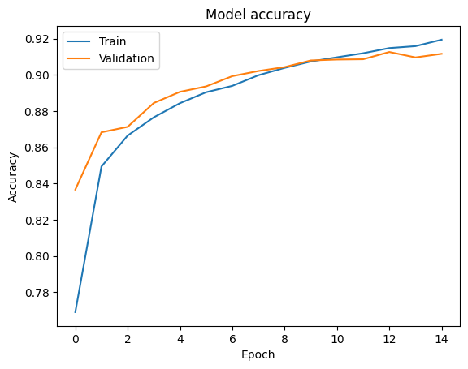

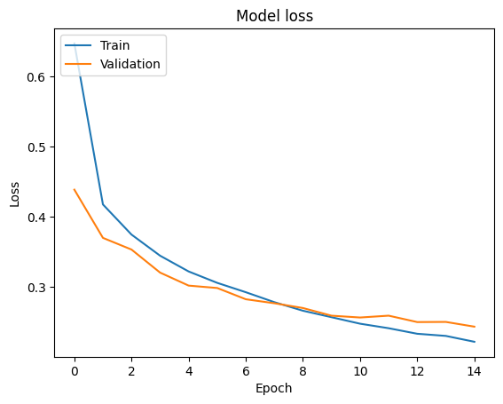

```python
plt.plot(final_model.history['accuracy'])
plt.plot(final_model.history['val_accuracy'])
plt.title('Model accuracy')
plt.ylabel('Accuracy')
plt.xlabel('Epoch')
plt.legend(['Train', 'Validation'], loc='upper left')
plt.show()

plt.plot(final_model.history['loss'])
plt.plot(final_model.history['val_loss'])
plt.title('Model loss')
plt.ylabel('Loss')
plt.xlabel('Epoch')
plt.legend(['Train', 'Validation'], loc='upper left')
plt.show()
```

```
313/313 ━━━━━━━━━━━━━━━━━━━━ 1s 3ms/step
```

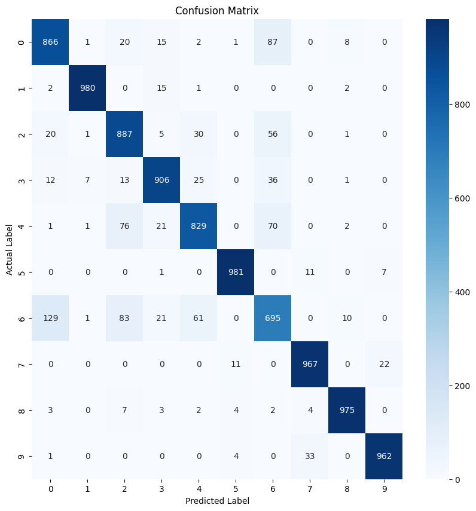

```python
from sklearn.metrics import confusion_matrix
import seaborn as sns

y_pred = model.predict(X_test)
y_pred_classes = np.argmax(y_pred, axis=1)
y_true = np.argmax(y_test, axis=1)

cm = confusion_matrix(y_true, y_pred_classes)

plt.figure(figsize=(10, 10))
sns.heatmap(cm, annot=True, fmt='d', cmap='Blues')
plt.title('Confusion Matrix')
plt.ylabel('Actual Label')
plt.xlabel('Predicted Label')
plt.show()
```

The confusion matrix highlights an interesting observation that label 6 is the most error prone by a wide margin, and it seems to be most confused with labels 0,2 and 4 so we did a bit of a deeper dive into it below.

#### All categories in the FASHION MINST Dataset

Label || Description

- 0 || T-shirt/top
- 1 || Trouser
- 2 || Pullover
- 3 || Dress
- 4 || Coat
- 5 || Sandal
- 6 || Shirt
- 7 || Sneaker
- 8 || Bag
- 9 || Ankle boot

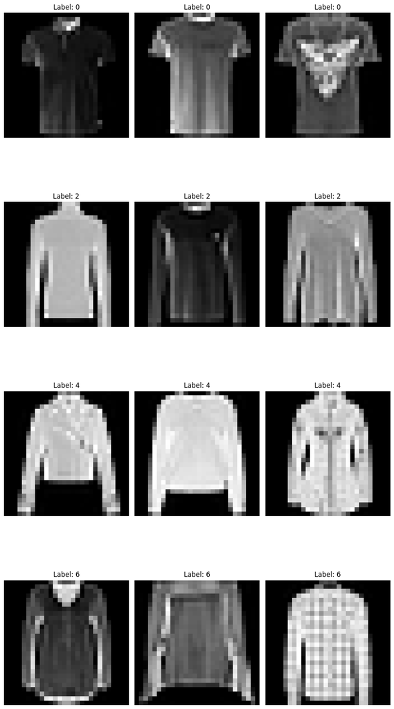

```python
# Reloading the Fashion MNIST dataset to get pre-processed data
(X_train, y_train), (X_test, y_test) = fashion_mnist.load_data()

# Function to display images for specific labels
def display_images_for_labels(labels, num_images=3):
    """Displays images for the specified labels from the Fashion MNIST dataset.

    Args:
        labels: A list of label values to display images for.
        num_images: The number of images to display for each label.
    """
    fig, axes = plt.subplots(len(labels), num_images, figsize=(10, 5 * len(labels)))

    for row, label in enumerate(labels):
        # Find indices of images with the current label
        indices = np.where(y_train == label)[0]

        # Select a random sample of images
        selected_indices = np.random.choice(indices, size=num_images, replace=False)

        for col, index in enumerate(selected_indices):
            # Display the image
            axes[row, col].imshow(X_train[index], cmap='gray')
            axes[row, col].set_title(f'Label: {label}')
            axes[row, col].axis('off')

    plt.tight_layout()
    plt.show()

# Display images for labels 0, 2, 4, and 6
display_images_for_labels([0,2,4,6])
```